# Tarea-7

Román Vélez Jiménez

2023-09-21

# Graficas de cuantiles normales

Para las siguientes distribuciones toma una muestra de tamaño 1000 y realiza 1) una gráfica de cuantiles muestrales

2. un histograma
3. una gráfica de cuantiles normales
- Log-normal(0, 2)
- Gamma(2, 2)
- Student-t con 1 grado de libertad
- Student-t con 10 grado de libertas

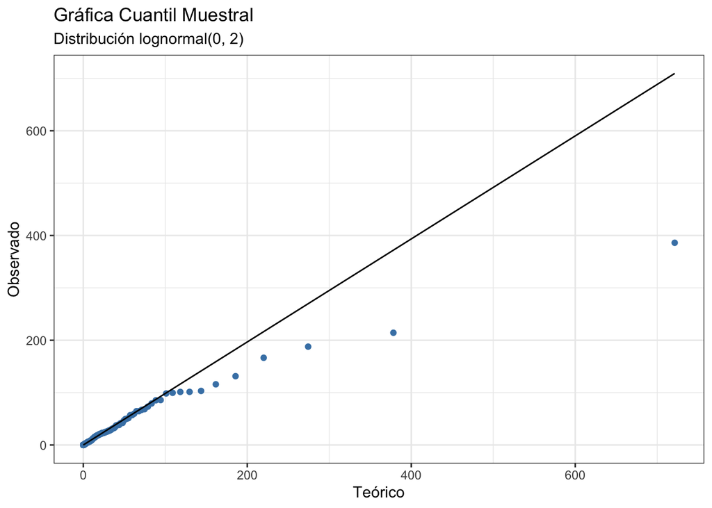

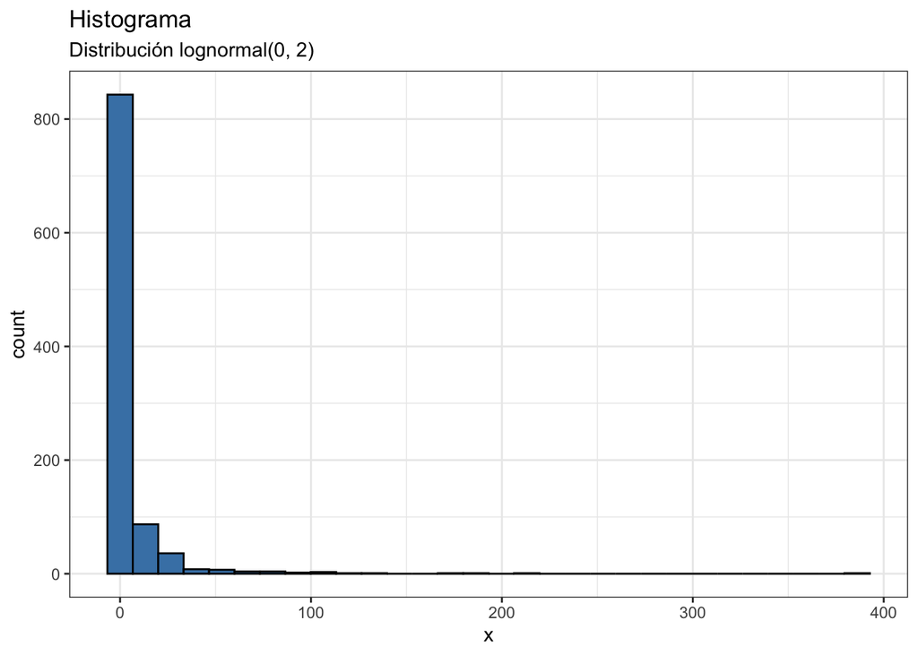

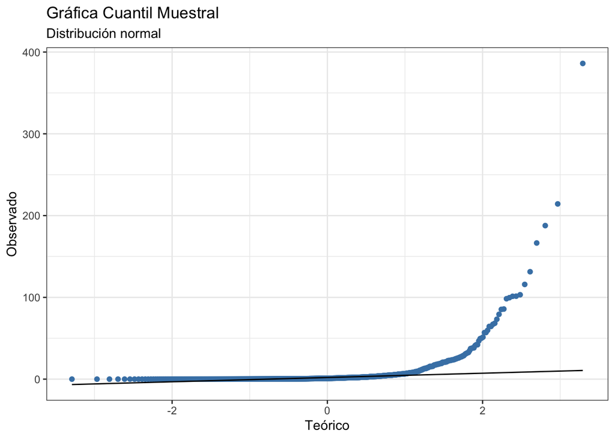

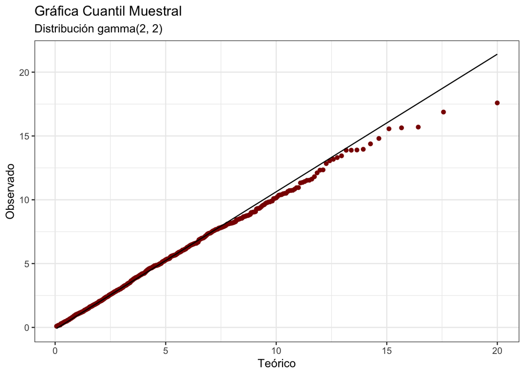

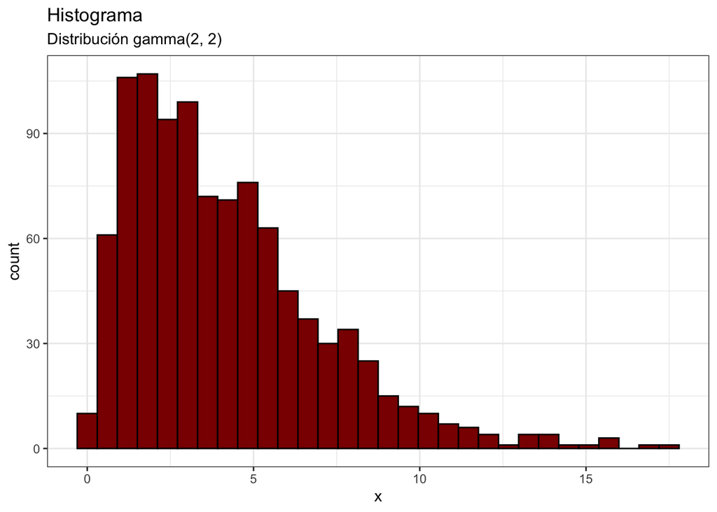

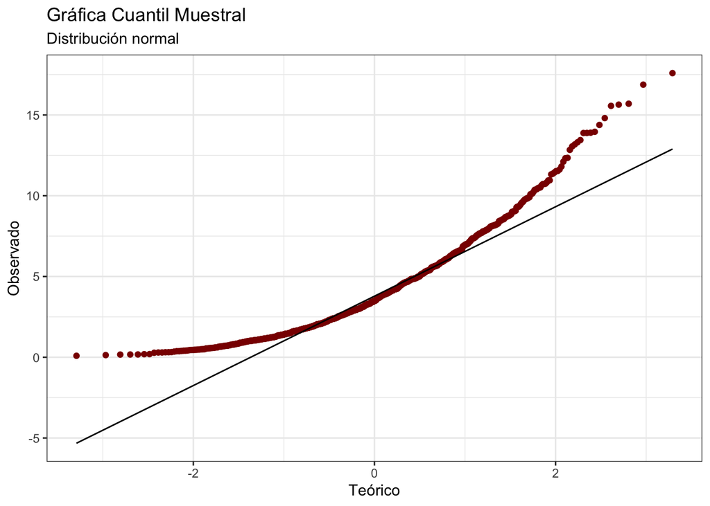

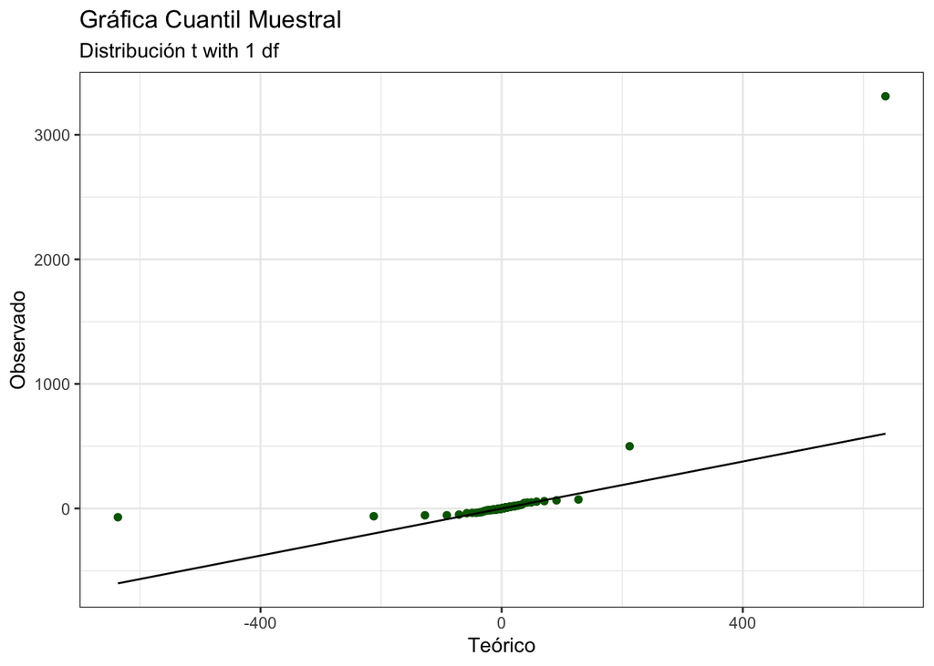

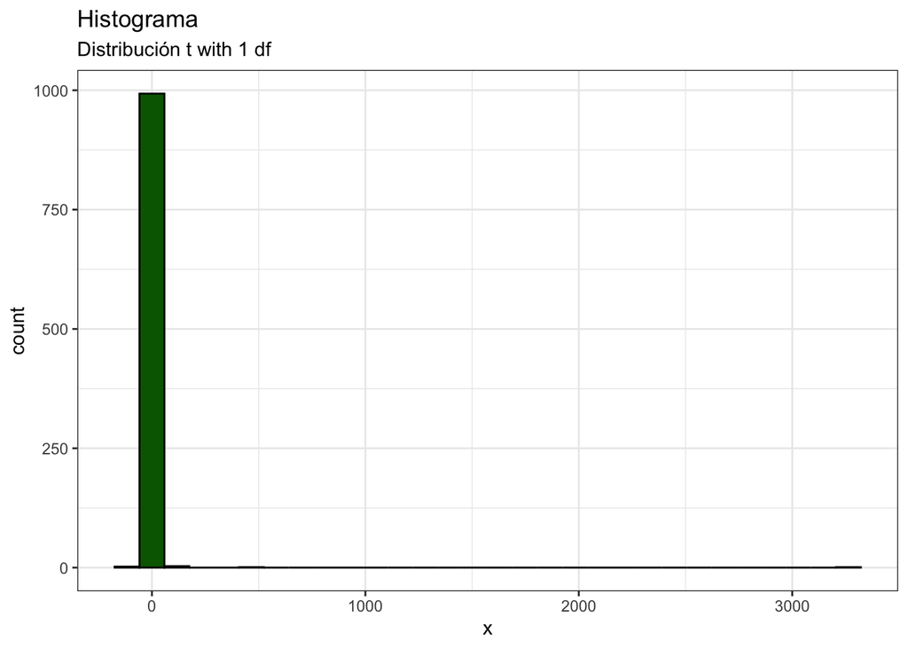

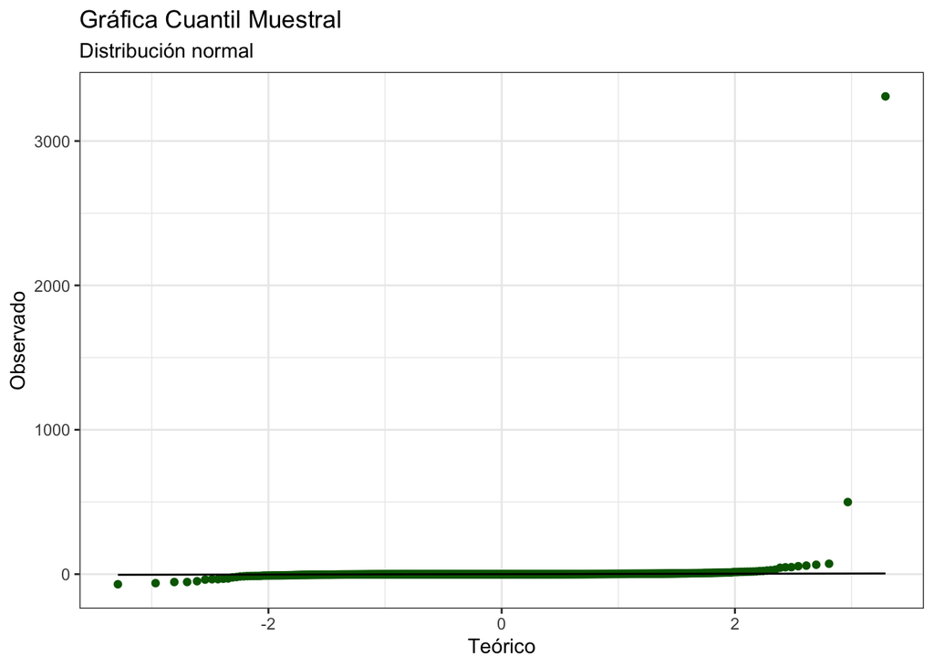

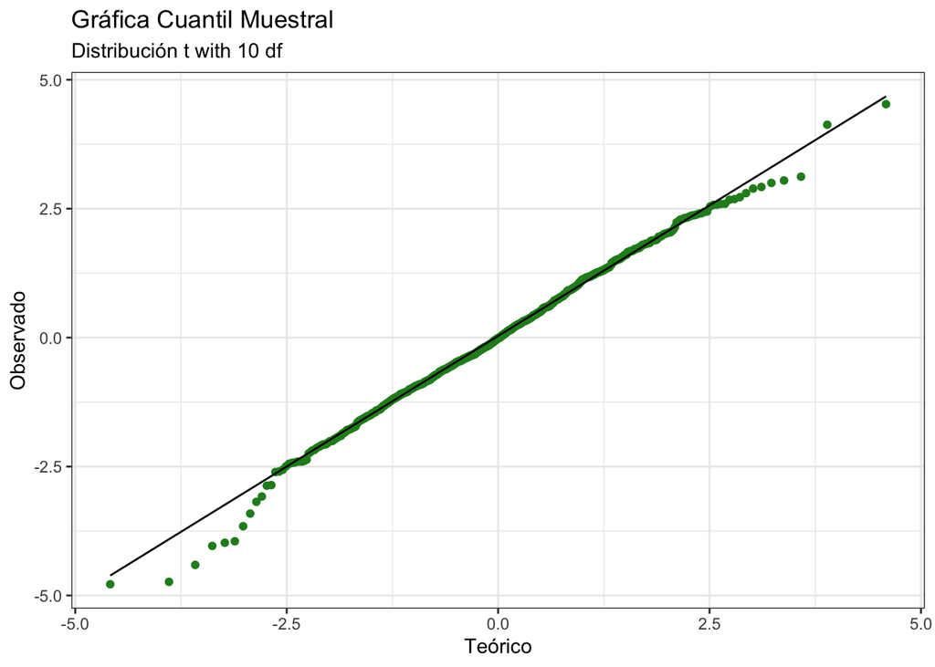

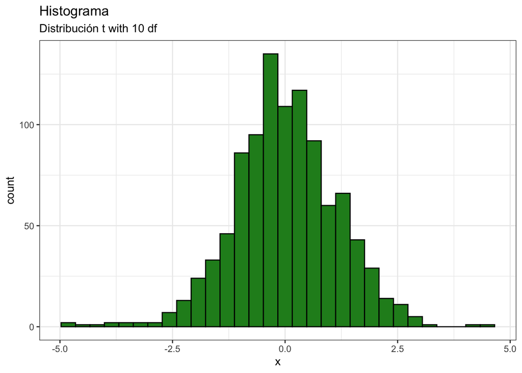

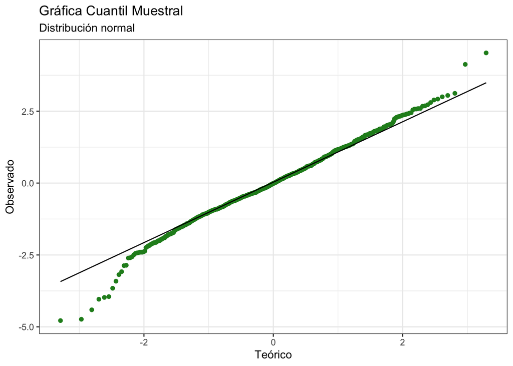

# Bootstrap

## 1. Rats experiment

1. Se realiza un experimento en el que se seleccionan 7 ratones de manera aleatoria de un total de 16 ratones. A los siete seleccionados se les suministra un tratamiento mientras que los restantes formarán el grupo de control. El objetivo del tratamiento es prolongar la supervivencia de los ratones. La siguiente tabla muestra el tiempo de supervivencia en días después de suministrar el tratamiento.

| Grupo | Datos | Tamaño de muestra |
| --- | --- | --- |
| Tratamiento | 94, 197, 16, 38, 99, 141, 23 | 7 |
| Control | 52, 104, 146, 10, 51, 30, 40, 27, 46 | 9 |

1. Usa las medias de las muestras para determinar si hay diferencias en los grupos, esto es calcula $\bar{x}-\bar{y}$.

```
## Diferencia de muestras 30.6349
```

```
## Hay 0.1578 de evidencia para pensar que tienen diferente supervivencia
```

2. Estima el error estándar de la diferencia usando bootsrap.

```
## El see del estimador es de 27.8417
```

5. Supongamos que deseamos comparar los grupos usando las medianas en lugar de las medias, estima la diferencia de las medias y usa bootstrap para estimar el error estándar de la diferencia.

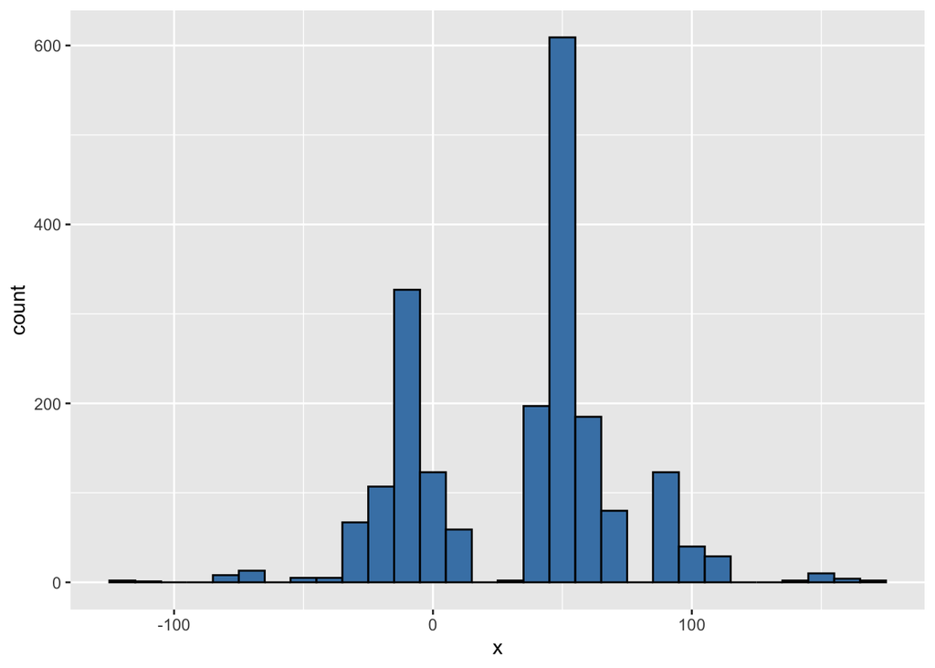

```
## La media del estimador es de la mediana es 33.8375
```

```
## El see del estimador es de 40.0716
```

## 2. Correlation Bootstrap

2. **Bootstrap correlación.** Nuevamente trabaja con los datos `primaria`, selecciona una muestra aleatoria de tamaño $100$ y utiliza el principio del *plug-in* para estimar la correlación entre la calificación de $y=$español $3$ y la de $z=$español $6$: $\hat{corr}(y,z)$. Usa bootstrap para calcular el error estándar de la estimación.

```
## # A tibble: 6 × 8
##      id cve_ent turno    tipo     esp_3 esp_6 n_eval_3 n_eval_6
##   <dbl>   <dbl> <chr>    <chr>    <dbl> <dbl>    <dbl>    <dbl>
## 1 38570      15 MATUTINO INDêGENA   550   483       13       19
## 2 38571      15 MATUTINO INDêGENA   485   490       17       18
## 3 38572      15 MATUTINO INDêGENA   462   385        9        9
## 4 38573      15 MATUTINO INDêGENA   646   613       33       26
## 5 38574      15 MATUTINO INDêGENA   508   452       26       35
## 6 38575      15 MATUTINO INDêGENA   502   500       10       13
```

This data are paired data, so the bootstrap should be by row

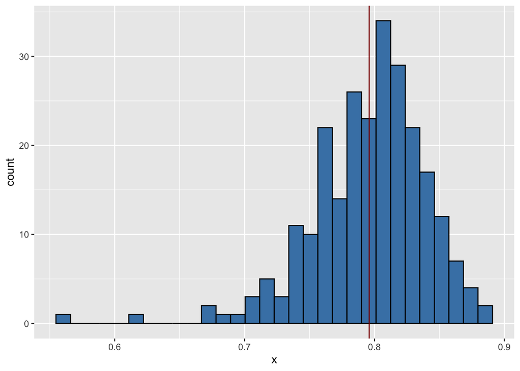

```
## La media del estimador es de la correlacion es 0.7959
```

```
## El see del estimador es de 0.0442
```